# Practica 4

Alejandro Caceres

2024-03-26

## Poisson (variable discreta)

El número de llamadas en una centralita sigue un modelo de poisson con $\lambda=25$.

Dibujemos la función de masa de probabilidad

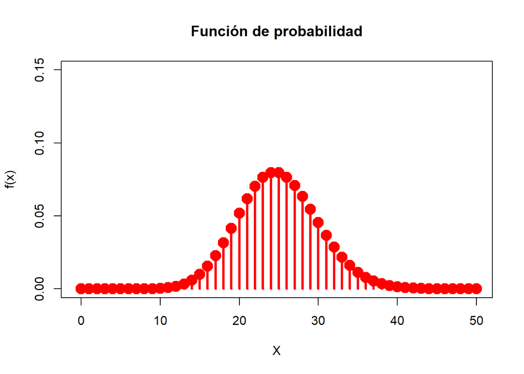

- ¿Cuál es la probabilidad de recibir 10 llamadas?

```
## [1] 0.000364985
```

- ¿Cuál es la probabilidad de recibir 30 llamadas?

```
## [1] 0.04541279
```

Dibujemos la funcion de distribución

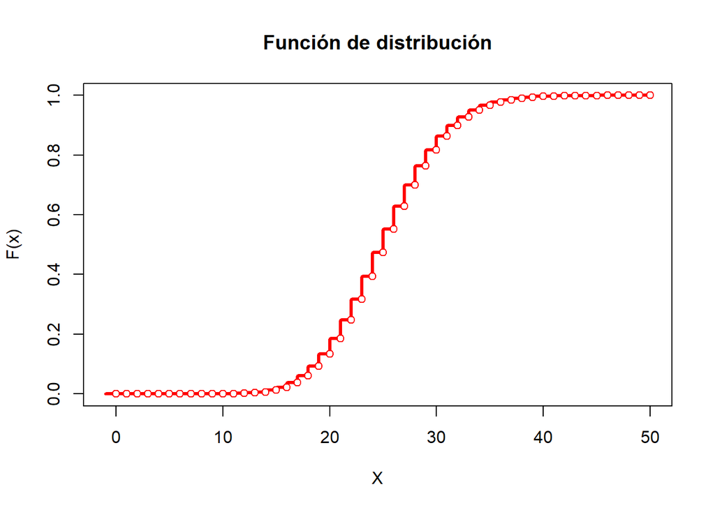

- ¿Cuál es la probabilidad de recibir como mucho 30 llamadas? $P(X \leq 30)$

```
## [1] 0.8633089
```

- ¿Cuál es la probabilidad de recibir como minimo 30 llamadas? $P(X \geq 30)$

```
## [1] 0.1821039
```

## Exponencial (variable continua)

El **tiempo** entre dos llamadas sigue una densidad de probabilidad exponencial con $\lambda=25$

Dibujemos la densiad de probabilidad

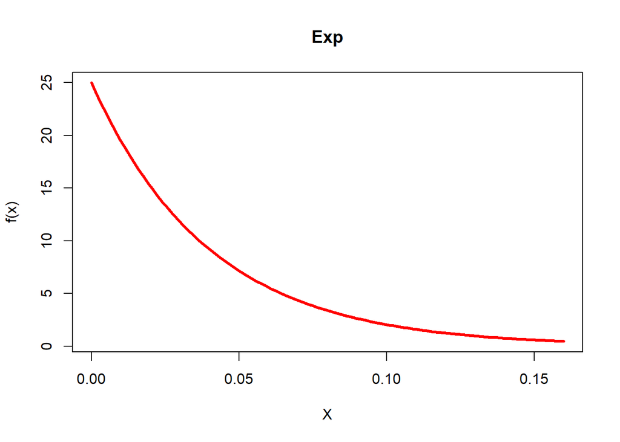

- ¿Cuál es la probabilidad de que pase un tiempo de 0.033 entre dos llamadas?

$P(X=0.033)=0$

- ¿Cuál es la probabilidad de que pase un tiempo de al menos 0.052 entre dos llamadas?

$P(X>0.052)= 1-F(0.052)$

Dibujemos la funcion de distribución

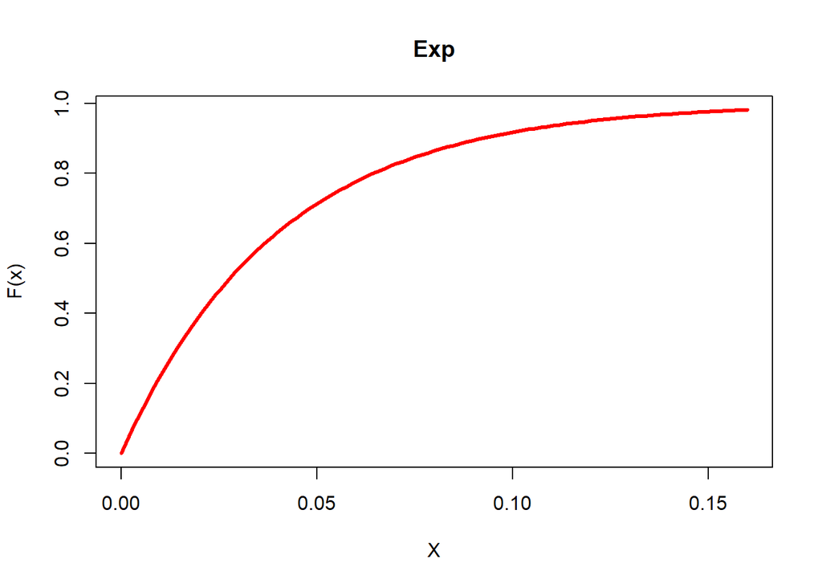

```
## [1] 0.2725318
```

- ¿Cuál tiempo de espera máximo que comprende un 75% de llamadas?

```
## [1] 0.05545177
```

- Hgamos 500000 simulaciones del tiempo entre dos llamadas, y calculemos su media

```
## [1] 0.03997478
```

El valor esperado de una variable exponencial es

```
## [1] 0.04
```